# Human Activity Correctness

AI

August 15, 2015

# Abstract

Using devices such as Jawbone Up, Nike FuelBand, and Fitbit it is now possible to collect a large amount of data about personal activity relatively inexpensively. These type of devices are part of the quantified self movement – a group of enthusiasts who take measurements about themselves regularly to improve their health, to find patterns in their behavior, or because they are tech geeks. One thing that people regularly do is quantify how much of a particular activity they do, but they rarely quantify how well they do it. In this project, your goal will be to use data from accelerometers on the belt, forearm, arm, and dumbell of 6 participants. They were asked to perform barbell lifts correctly and incorrectly in 5 different ways. More information is available from the website [here][0]

```r
library(caret)
library(rattle)
library(doParallel)
registerDoParallel(cores = 6)
```

# Getting and Cleaning Data

Data is prepartitioned into two sets. One to be used for training and crossvalidation as necessary and there is also a validation set to validate the accuracy

```r
if(!file.exists('pml-training.csv'))
  download.file('https://d396qusza40orc.cloudfront.net/predmachlearn/pml-training.csv')
if(!file.exists('pml-testing.csv'))
  download.file('https://d396qusza40orc.cloudfront.net/predmachlearn/pml-testing.csv')
Data <- read.csv('pml-training.csv')
validateData <- read.csv('pml-testing.csv')
```

Before any exploratory analysis, data is immediately partitioned into training and test

```r
set.seed(3223)
inTrain <- createDataPartition(Data$classe, p = 0.7, list = FALSE)
trainData <- Data[inTrain, ]
testData <- Data[-inTrain,]

trainColNums <- unname(colSums(is.na(trainData)))
validateColNums <- unname(colSums(is.na(validateData)))

trainNACols <- which(trainColNums != 0)
validateNACols <- which(validateColNums != 0)
all(trainNACols %in% validateNACols)
```

```
## [1] TRUE
```

It can be seen that there are several NA columns in both training and validation data sets. **A interesting observation is that list of columns with NAs in validation data is a superset of list of columns with NAs in training data** Also, the columans with NAs have less than 1% of non NA values. It doesn’t make sense to impute them in this case. So, they are discarded.

A subset of columns that are fully valid in both training and validation sets are used for modeling.

```r
cleanTrainData <- trainData[,-c(validateNACols)]
cleanTestData <- testData[,-c(validateNACols)]
cleanValidateData <- validateData[,-c(validateNACols)]

#Remove X, user_name, raw_timestamp_part_1, raw_timestamp_part_2, cvtd_timestamp, new_window, num_window
cleanTrainData <- cleanTrainData[,-c(1,2,3,4,5,6,7)]
cleanTestData <- cleanTestData[,-c(1,2,3,4,5,6,7)]
cleanValidateData <- cleanValidateData[,-c(1,2,3,4,5,6,7)]

#Extract Outcome
trainOutcome <- cleanTrainData[,c('classe')]
testOutcome <- cleanTestData[,c('classe')]

#Remove outcome from training data
cleanTrainData <- cleanTrainData[, -c(53)]
cleanTestData <- cleanTestData[,-c(53)]

#Remove problem_id from testing data
cleanValidateData <- cleanValidateData[, -c(53)]
```

Other irrelevent variables like time stamp, subject id, window etc are also removed from consideration.

# Exploratory Analysis

Sigular value decomposition is performed to get an understanding of the data

```r
svd1 <- svd(scale(cleanTrainData))
maxcontrib1 <- which.max(svd1$v[,1])
maxcontrib2 <- which.max(svd1$v[,2])

names(cleanTrainData)[maxcontrib1]
```

```
## [1] "accel_belt_z"
```

```r
names(cleanTrainData)[maxcontrib2]
```

```
## [1] "accel_belt_x"
```

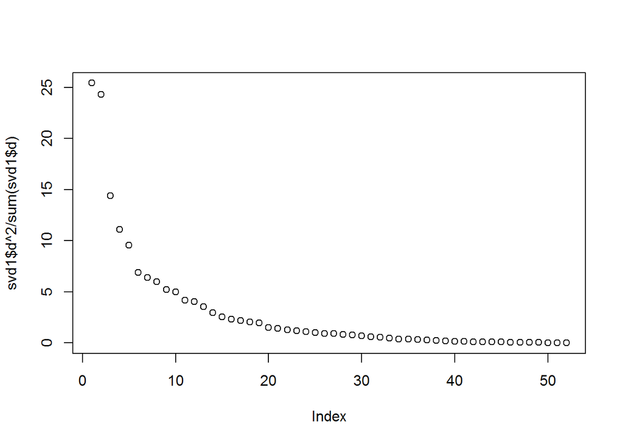

```r
plot(svd1$d^2/sum(svd1$d))
```

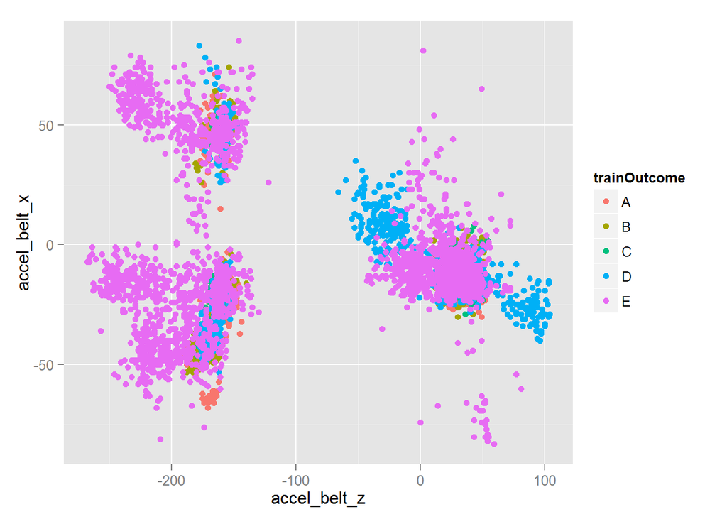

```r
plot <- ggplot(data = cleanTrainData, aes(x=cleanTrainData[,maxcontrib1], y=cleanTrainData[,maxcontrib2]))
plot + geom_point(aes(col = trainOutcome)) + labs(x=names(cleanTrainData)[maxcontrib1], y=names(cleanTrainData)[maxcontrib2])
```

The top 2 contributors to this classification problem seem to be from the belt. They are accel_belt_z and accel_belt_x.

From the first plot, variance is explained by a lot of variables. Looks like we need atleast 45 variables to properly explain the model.

Second plot shows how the top two contributers color coded with the activity. Although they seem to create clusters of activity, just the two contributers are not sufficient to seperate them. This is in line with findings from first plot which shows just two contributers do not explain much of the variance.

# Modeling and Machine Learning

Since random forests are good at classifications, they will be used to predict validation data.

```r
preProc1 <- preProcess(cleanTrainData, method = 'pca')

set.seed(3421)
fit1 <- train(y = trainOutcome, x = predict(preProc1, cleanTrainData), method = 'rf')
validatePrediction <- predict(fit1, predict(preProc1, cleanTestData))

confusionMatrix(validatePrediction, testOutcome)
```

```
## Confusion Matrix and Statistics
##
##           Reference
## Prediction    A    B    C    D    E
##          A 1654   15    2    1    0
##          B    9 1108   17    2    4
##          C    6   16  997   33    9
##          D    4    0    7  928    9
##          E    1    0    3    0 1060
##
## Overall Statistics
##
##                Accuracy : 0.9766
##                  95% CI : (0.9724, 0.9803)
##     No Information Rate : 0.2845
##     P-Value [Acc > NIR] : < 2.2e-16
##
##                   Kappa : 0.9703
##  Mcnemar's Test P-Value : 1.027e-05
##
## Statistics by Class:
##
##                      Class: A Class: B Class: C Class: D Class: E
## Sensitivity            0.9881   0.9728   0.9717   0.9627   0.9797
## Specificity            0.9957   0.9933   0.9868   0.9959   0.9992
## Pos Pred Value         0.9892   0.9719   0.9397   0.9789   0.9962
## Neg Pred Value         0.9953   0.9935   0.9940   0.9927   0.9954
## Prevalence             0.2845   0.1935   0.1743   0.1638   0.1839
## Detection Rate         0.2811   0.1883   0.1694   0.1577   0.1801
## Detection Prevalence   0.2841   0.1937   0.1803   0.1611   0.1808
## Balanced Accuracy      0.9919   0.9830   0.9793   0.9793   0.9894
```

```r
testPrediction <- predict(fit1, predict(preProc1, cleanValidateData))
```

Since the model provides a good accuracy, other models are not explored and this model is used to predict validation data.

**The expected out of sample error in validation set from cross validation is 2.4%**